# Project 3

STATS 220 Semester One 2026

Yifeng Deng

2026-04-27

## Introduction

For this project, I searched for photos on Pexels using the two words **nice dog**. I chose these words because dogs are popular pets, and I expected this search to return many different photos with different sizes, orientations, and photographers. The search URL I used was https://www.pexels.com/search/nice%20dog/.

[figure not shown]

First row of Pexels photos

The table below shows the URLs of the photos in my selected photos data frame.

```r
selected_photos %>%
  select(url) %>%
  knitr::kable()
```

| url |
| --- |
| https://www.pexels.com/photo/a-dogs-head-16366116/ |
| https://www.pexels.com/photo/elderly-woman-walking-dog-in-provence-street-36984191/ |
| https://www.pexels.com/photo/obedient-german-shepherd-19777863/ |
| https://www.pexels.com/photo/happy-dog-relaxing-on-a-sunny-beach-36693032/ |
| https://www.pexels.com/photo/portrait-of-a-brown-dog-on-a-sandy-beach-36563950/ |
| https://www.pexels.com/photo/a-dog-sitting-on-the-floor-with-its-tongue-hanging-out-28179967/ |
| https://www.pexels.com/photo/happy-black-labrador-on-leash-in-ciudad-de-mexico-33834386/ |
| https://www.pexels.com/photo/cuddly-white-dog-in-sunlit-street-scene-29897846/ |
| https://www.pexels.com/photo/portrait-of-a-white-labrador-retriever-18023711/ |
| https://www.pexels.com/photo/close-up-portrait-of-a-beige-mixed-breed-dog-36563948/ |
| https://www.pexels.com/photo/basque-shepherd-dog-19722865/ |
| https://www.pexels.com/photo/puppy-sitting-by-wall-15889519/ |
| https://www.pexels.com/photo/close-up-of-a-mixed-breed-dog-on-a-leash-outdoors-33834413/ |
| https://www.pexels.com/photo/friendly-dog-lying-on-paved-urban-streets-32736000/ |
| https://www.pexels.com/photo/close-up-shot-of-a-dog-6733261/ |
| https://www.pexels.com/photo/close-up-portrait-of-a-german-shepherd-dog-32616351/ |
| https://www.pexels.com/photo/close-up-of-a-cream-colored-dog-with-blue-eyes-37023064/ |
| https://www.pexels.com/photo/australian-cattle-dog-15819832/ |
| https://www.pexels.com/photo/adorable-scruffy-dog-on-leash-in-mexico-city-33834383/ |
| https://www.pexels.com/photo/close-up-of-a-tricolor-border-collie-sitting-indoors-37049114/ |

## Key features of my selected photos

```r
# My personal purpose: calculate summary values for my selected nice dog photos.

mean_width <- selected_photos$width %>%
  mean(na.rm = TRUE)

median_height <- selected_photos$height %>%
  median(na.rm = TRUE)

number_landscape <- (selected_photos$orientation == "landscape") %>%
  sum(na.rm = TRUE)

# My personal purpose: compare photo size across different orientation groups.
grouped_photos <- selected_photos %>%
  group_by(orientation) %>%
  summarise(
    mean_width = mean(width, na.rm = TRUE),
    mean_height = mean(height, na.rm = TRUE)
  )

# My personal purpose: save one summary value from the grouped data frame.
mean_width_landscape <- grouped_photos$mean_width[
  grouped_photos$orientation == "landscape"
]
```

The mean width of my selected photos is 4019.6 pixels.

The median height of my selected photos is 5448 pixels.

There are 4 landscape photos in my selected photos.

The mean width of the landscape photos is 5364 pixels.

## Creativity

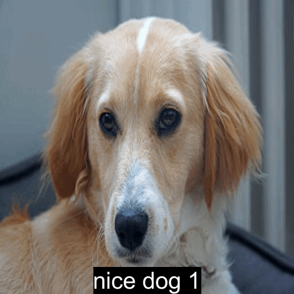

My creativity GIF

My project demonstrates creativity because I used photo data from the Pexels API to create an animated GIF instead of only writing a static report. I used the `medium` photo URL variable from my selected photos data frame and used skills from earlier modules to read, resize, annotate, combine, animate, and save images. The GIF includes text on each photo, so it is not only a collection of images but a simple visual presentation of my selected dog photos. This connects data collection, data manipulation, and image creation together in one project.

## Learning reflection

One important idea I learned from Module 3 is how to create new variables from existing data. For example, I used the width and height variables to create an aspect ratio variable, and then used that to create an orientation variable. This helped me understand how raw data can be changed into more useful information for analysis. I also learned how to use filtering to select a smaller group of photos from a larger data frame.

I am more curious about how APIs can be used to collect different kinds of data from websites. I would like to explore how image data, text data, and other web data can be combined in one project. I am also interested in learning more about how computers can analyse image features such as size, colour, and layout.

## Appendix

```r
############
# Part A
############
# Search words used: nice dog
# Search URL:https://www.pexels.com/search/nice%20dog/
# Describe three things:
# 1. The photos vary in size and orientation. Some are portrait while others are landscape.

# 2. Many of the photos appear to be landscape, suggesting that wide images are more common.

# 3. The photos are taken by different photographers, with names of varying lengths.


############
# Part B
############

#api_key <- "YOUR_API_KEY_HERE"

############
# Part C
############
library(tidyverse)
library(httr)
library(magick)
# My personal purpose: get the key from the Pexels API to get photo data
api_key <- "lIAuQtsixxJfacvQSk45XhgymYu7lzIU7JrJQFxrKVP36TUdMNWOhi66"

# My personal purpose: get the url from the Pexels API to get photo data for my Project 3 search words,
# my search word is "nice dog",80 photos per page.

url <- "https://api.pexels.com/v1/search?query=nice%20dog&per_page=80"

response <- httr::GET(url,
                      add_headers(Authorization = api_key))

data <- httr::content(response,
                      as = "parsed",
                      type = "application/json")

# My personal purpose: turn the nested API photo data into a flat data frame.
photo_data <- tibble(photos = data$photos) %>%
  unnest_wider(photos) %>%
  unnest_wider(src)
# My personal purpose: create new variables to help describe and select photos.
#1. mutate() function create three NEW variables aspect_ratio,orientation,photographer_name_length,
#2. categorical variable is a three level variable,so it is with no more than four levels.
#3.selected_photos has both numeric and character variables:we have numeric variable such as width,and
# character variable such as orientation
#4. I use filter() to select around 20 photos based on a condition,and slice_head() to keep the first 20 photos.

selected_photos <- photo_data %>%
  mutate(
    aspect_ratio = width / height,
    orientation = case_when(
      aspect_ratio > 1 ~ "landscape",
      aspect_ratio < 1 ~ "portrait",
      TRUE ~ "square"
    ),
    photographer_name_length = nchar(photographer)
  ) %>%
  filter(
    photographer_name_length >= 15
  ) %>%
  select(
    id,
    width,
    height,
    aspect_ratio,
    orientation,
    photographer,
    photographer_name_length,
    url,
    original,
    medium
  )  %>%
  slice_head(n = 20)

# My personal purpose: save my selected photo data in the project.
write_csv(selected_photos, "selected_photos.csv")


############
# Part D
############
# My personal purpose: calculate summary values for my selected nice dog photos.

mean_width <- selected_photos$width %>%
  mean(na.rm = TRUE)
mean_width

median_height <- selected_photos$height %>%
  median(na.rm = TRUE)
median_height

number_landscape <- (selected_photos$orientation == "landscape") %>%
  sum(na.rm = TRUE)
number_landscape


# My personal purpose: compare photo size across different orientation groups.
grouped_photos <- selected_photos %>%
  group_by(orientation) %>%
  summarise(
    mean_width = mean(width, na.rm = TRUE),
    mean_height = mean(height, na.rm = TRUE)
  )
grouped_photos

# My personal purpose: save one summary value from the grouped data frame.
mean_width_landscape <- grouped_photos$mean_width[
  grouped_photos$orientation == "landscape"
]
mean_width_landscape

############
# Part E
############


# My personal purpose: create an animated GIF using three selected dog photos.
#image_resize("500x500!") must have“！”, missing "!" will lead the image not scale,and show the black background.
# Image 1
image1 <- image_read(selected_photos$medium[1]) %>%
  image_resize("500x500!") %>%
  image_annotate(
    text = "nice dog 1",
    size = 40,
    color = "white",
    boxcolor = "black",
    gravity = "south"
  )

# Image 2
image2 <- image_read(selected_photos$medium[2]) %>%
  image_resize("500x500!") %>%
  image_annotate(
    text = "nice dog 2",
    size = 40,
    color = "white",
    boxcolor = "black",
    gravity = "south"
  )

# Image 3
image3 <- image_read(selected_photos$medium[3]) %>%
  image_resize("500x500!") %>%
  image_annotate(
    text = "nice dog 3",
    size = 40,
    color = "white",
    boxcolor = "black",
    gravity = "south"
  )

# Combine images into frames
image_frames <- c(image1, image2, image3)

# Create animated GIF
creativity_gif <- image_animate(
  image_frames,
  fps = 1
)

# Save GIF
image_write(
  creativity_gif,
  "creativity.gif"
)
creativity_gif
```

````r
---
title: "Project 3"
author: "Yifeng Deng"
subtitle: "STATS 220 Semester One 2026"
output:
  html_document:
    code_folding: hide
    self_contained: true
date: "2026-04-27"
---

```{r setup, include=FALSE}
knitr::opts_chunk$set(echo=TRUE, message=FALSE, warning=FALSE, error=FALSE)
library(tidyverse)
selected_photos <- read_csv("selected_photos.csv")
```

```{css echo=FALSE}

```

## Introduction

For this project, I searched for photos on Pexels using the two words **nice dog**. I chose these words because dogs are popular pets, and I expected this search to return many different photos with different sizes, orientations, and photographers. The search URL I used was [https://www.pexels.com/search/nice%20dog/](https://www.pexels.com/search/nice%20dog/).

![First row of Pexels photos](top_photos.png)

Before exploring the data from the Pexels API, I noticed three features about the photos returned by my search. First, the photos vary in size and orientation. Some are portrait while others are landscape. Second, many of the photos appear to be landscape, suggesting that wide images are more common. Third, the photos are taken by different photographers, with names of varying lengths.

The table below shows the URLs of the photos in my selected photos data frame.

```{r}
selected_photos %>%
  select(url) %>%
  knitr::kable()
```

## Key features of my selected photos

```{r}
# My personal purpose: calculate summary values for my selected nice dog photos.

mean_width <- selected_photos$width %>%
  mean(na.rm = TRUE)

median_height <- selected_photos$height %>%
  median(na.rm = TRUE)

number_landscape <- (selected_photos$orientation == "landscape") %>%
  sum(na.rm = TRUE)

# My personal purpose: compare photo size across different orientation groups.
grouped_photos <- selected_photos %>%
  group_by(orientation) %>%
  summarise(
    mean_width = mean(width, na.rm = TRUE),
    mean_height = mean(height, na.rm = TRUE)
  )

# My personal purpose: save one summary value from the grouped data frame.
mean_width_landscape <- grouped_photos$mean_width[
  grouped_photos$orientation == "landscape"
]
```

The mean width of my selected photos is `r round(mean_width, 1)` pixels.

The median height of my selected photos is `r round(median_height, 1)` pixels.

There are `r number_landscape` landscape photos in my selected photos.

The mean width of the landscape photos is `r round(mean_width_landscape, 1)` pixels.

## Creativity

![My creativity GIF](creativity.gif)

My project demonstrates creativity because I used photo data from the Pexels API to create an animated GIF instead of only writing a static report. I used the `medium` photo URL variable from my selected photos data frame and used skills from earlier modules to read, resize, annotate, combine, animate, and save images. The GIF includes text on each photo, so it is not only a collection of images but a simple visual presentation of my selected dog photos. This connects data collection, data manipulation, and image creation together in one project.

## Learning reflection

One important idea I learned from Module 3 is how to create new variables from existing data. For example, I used the width and height variables to create an aspect ratio variable, and then used that to create an orientation variable. This helped me understand how raw data can be changed into more useful information for analysis. I also learned how to use filtering to select a smaller group of photos from a larger data frame.

I am more curious about how APIs can be used to collect different kinds of data from websites. I would like to explore how image data, text data, and other web data can be combined in one project. I am also interested in learning more about how computers can analyse image features such as size, colour, and layout.

## Appendix

```{r file='exploration.R', eval=FALSE, echo=TRUE}

```

```{r file='project3_report.Rmd', eval=FALSE, echo=TRUE}

```
````